# Computational Data Analysis Report

Han_24643978

2025-10-04

# Introduction:

The box office market share is expected to increase by USD 21.25 billion from 2020 to 2025, and the market’s growth momentum will accelerate at a CAGR of 21.78% (Technavio, 2021). The increase in the number of movie screens, the surging success of movies due to the increasing use of animation, and growing international collaboration in film making will offer immense growth opportunities.

In this report I will analyse the relationships between box office, economic, population trends and do the model prediction movie revenue.

# Task 1. Load Required Packages

```r
# Global options

knitr::opts_chunk$set(
  echo    = TRUE,
  message = FALSE,
  warning = FALSE
)

suppressPackageStartupMessages({
  library(tidyverse)
  library(GGally)
  library(rpart)
  library(rpart.plot)
  library(caret)
  library(randomForest)
  library(conflicted)
  library(pROC)
  library(lime)
  library(ggplot2)
  library(dplyr)
  library(tibble)

})

# Silence conflict messages
suppressMessages({
  conflicts_prefer(dplyr::filter)
  conflicts_prefer(dplyr::mutate)
  conflicts_prefer(dplyr::select)
  conflicts_prefer(dplyr::lag)
  conflicted::conflicts_prefer(lime::explain)
  conflicted::conflicts_prefer(ggplot2::margin)
})

if (!exists("%>%")) `%>%` <- dplyr::`%>%`
set.seed(42)
```

# Task2. Load datasets

```r
box_office <- read.csv("../data/Box_office_data(2000-2024).csv")
gdp        <- read.csv("../data/GDP_2020_2024.csv")
population <- read.csv("../data/Population_2000_2024.csv")
```

# Data overview

```r
str(box_office)
```

```
## 'data.frame':    5000 obs. of  13 variables:
##  $ Rank                : int  1 2 3 4 5 6 7 8 9 10 ...
##  $ Release.Group       : chr  "Mission: Impossible II" "Gladiator" "Cast Away" "What Women Want" ...
##  $ X.Worldwide         : num  5.46e+08 4.61e+08 4.30e+08 3.74e+08 3.50e+08 ...
##  $ X.Domestic          : int  215409889 187705427 233632142 182811707 137748063 260745620 166244045 182618434 157299718 155464351 ...
##  $ Domestic..          : num  39.4 40.8 54.4 48.9 39.4 75.4 50.3 55.6 53.1 53.3 ...
##  $ X.Foreign           : int  330978219 272878533 196000000 191300000 212074702 85096578 164200000 146100000 139039810 135956000 ...
##  $ Foreign..           : num  60.6 59.2 45.6 51.1 60.6 24.6 49.7 44.4 46.9 46.7 ...
##  $ Year                : int  2000 2000 2000 2000 2000 2000 2000 2000 2000 2000 ...
##  $ Genres              : chr  "Adventure, Action, Thriller" "Action, Drama, Adventure" "Adventure, Drama" "Comedy, Romance" ...
##  $ Rating              : chr  "6.126/10" "8.217/10" "7.663/10" "6.45/10" ...
##  $ Vote_Count          : int  6741 19032 11403 3944 2530 7591 5916 2312 11355 1818 ...
##  $ Original_Language   : chr  "en" "en" "en" "en" ...
##  $ Production_Countries: chr  "United States of America" "United Kingdom, United States of America" "United States of America" "United Kingdom, United States of America" ...
```

```r
summary(box_office)
```

```
##       Rank        Release.Group       X.Worldwide          X.Domestic
##  Min.   :  1.00   Length:5000        Min.   :1.666e+06   Min.   :        0
##  1st Qu.: 50.75   Class :character   1st Qu.:2.466e+07   1st Qu.:    92752
##  Median :100.50   Mode  :character   Median :4.845e+07   Median : 17984212
##  Mean   :100.50                      Mean   :1.192e+08   Mean   : 44725233
##  3rd Qu.:150.25                      3rd Qu.:1.198e+08   3rd Qu.: 53868472
##  Max.   :200.00                      Max.   :2.799e+09   Max.   :936662225
##
##    Domestic..       X.Foreign           Foreign..           Year
##  Min.   :  0.00   Min.   :0.000e+00   Min.   :  0.00   Min.   :2000
##  1st Qu.:  0.20   1st Qu.:1.371e+07   1st Qu.: 42.20   1st Qu.:2006
##  Median : 37.05   Median :3.019e+07   Median : 62.95   Median :2012
##  Mean   : 35.74   Mean   :7.449e+07   Mean   : 64.26   Mean   :2012
##  3rd Qu.: 57.80   3rd Qu.:7.212e+07   3rd Qu.: 99.80   3rd Qu.:2018
##  Max.   :100.00   Max.   :1.994e+09   Max.   :100.00   Max.   :2024
##
##     Genres             Rating            Vote_Count      Original_Language
##  Length:5000        Length:5000        Min.   :    0.0   Length:5000
##  Class :character   Class :character   1st Qu.:  205.2   Class :character
##  Mode  :character   Mode  :character   Median : 1035.5   Mode  :character
##                                        Mean   : 2531.6
##                                        3rd Qu.: 3065.0
##                                        Max.   :36753.0
##                                        NA's   :170
##  Production_Countries
##  Length:5000
##  Class :character
##  Mode  :character
##
##
##
##
```

```r
str(gdp)
```

```
## 'data.frame':    266 obs. of  29 variables:
##  $ Country.Name  : chr  "Aruba" "Africa Eastern and Southern" "Afghanistan" "Africa Western and Central" ...
##  $ Country.Code  : chr  "ABW" "AFE" "AFG" "AFW" ...
##  $ Indicator.Name: chr  "GDP (current US$)" "GDP (current US$)" "GDP (current US$)" "GDP (current US$)" ...
##  $ Indicator.Code: chr  "NY.GDP.MKTP.CD" "NY.GDP.MKTP.CD" "NY.GDP.MKTP.CD" "NY.GDP.MKTP.CD" ...
##  $ X2000         : num  1.87e+09 2.87e+11 3.52e+09 1.42e+11 9.13e+09 ...
##  $ X2001         : num  1.90e+09 2.61e+11 2.81e+09 1.50e+11 8.94e+09 ...
##  $ X2002         : num  1.96e+09 2.68e+11 3.83e+09 1.79e+11 1.53e+10 ...
##  $ X2003         : num  2.04e+09 3.56e+11 4.52e+09 2.08e+11 1.78e+10 ...
##  $ X2004         : num  2.25e+09 4.43e+11 5.22e+09 2.59e+11 2.36e+10 ...
##  $ X2005         : num  2.36e+09 5.17e+11 6.20e+09 3.17e+11 3.70e+10 ...
##  $ X2006         : num  2.47e+09 5.80e+11 6.97e+09 4.03e+11 5.24e+10 ...
##  $ X2007         : num  2.68e+09 6.66e+11 9.75e+09 4.72e+11 6.53e+10 ...
##  $ X2008         : num  2.84e+09 7.14e+11 1.01e+10 5.75e+11 8.85e+10 ...
##  $ X2009         : num  2.55e+09 7.15e+11 1.24e+10 5.15e+11 7.03e+10 ...
##  $ X2010         : num  2.45e+09 8.49e+11 1.59e+10 6.06e+11 8.38e+10 ...
##  $ X2011         : num  2.64e+09 9.45e+11 1.78e+10 6.91e+11 1.12e+11 ...
##  $ X2012         : num  2.62e+09 9.53e+11 1.99e+10 7.48e+11 1.28e+11 ...
##  $ X2013         : num  2.73e+09 9.62e+11 2.01e+10 8.44e+11 1.32e+11 ...
##  $ X2014         : num  2.79e+09 9.79e+11 2.05e+10 9.04e+11 1.36e+11 ...
##  $ X2015         : num  2.96e+09 8.98e+11 1.91e+10 7.78e+11 9.05e+10 ...
##  $ X2016         : num  2.98e+09 8.29e+11 1.81e+10 7.00e+11 5.28e+10 ...
##  $ X2017         : num  3.09e+09 9.73e+11 1.88e+10 6.94e+11 7.37e+10 ...
##  $ X2018         : num  3.28e+09 1.01e+12 1.81e+10 7.78e+11 7.95e+10 ...
##  $ X2019         : num  3.40e+09 1.01e+12 1.88e+10 8.33e+11 7.09e+10 ...
##  $ X2020         : num  2.48e+09 9.33e+11 2.00e+10 7.97e+11 4.85e+10 ...
##  $ X2021         : num  2.93e+09 1.09e+12 1.43e+10 8.58e+11 6.65e+10 ...
##  $ X2022         : num  3.28e+09 1.19e+12 1.45e+10 8.94e+11 1.04e+11 ...
##  $ X2023         : num  3.65e+09 1.18e+12 1.72e+10 8.15e+11 8.49e+10 ...
##  $ X2024         : num  NA 1.29e+12 NA 6.70e+11 8.04e+10 ...
```

```r
summary(gdp)
```

```
##  Country.Name       Country.Code       Indicator.Name     Indicator.Code
##  Length:266         Length:266         Length:266         Length:266
##  Class :character   Class :character   Class :character   Class :character
##  Mode  :character   Mode  :character   Mode  :character   Mode  :character
##
##
##
##
##      X2000               X2001               X2002
##  Min.   :1.507e+07   Min.   :1.396e+07   Min.   :1.684e+07
##  1st Qu.:3.035e+09   1st Qu.:2.814e+09   1st Qu.:3.034e+09
##  Median :1.439e+10   Median :1.418e+10   Median :1.459e+10
##  Mean   :9.869e+11   Mean   :9.800e+11   Mean   :1.003e+12
##  3rd Qu.:1.912e+11   3rd Qu.:1.918e+11   3rd Qu.:1.957e+11
##  Max.   :3.387e+13   Max.   :3.366e+13   Max.   :3.496e+13
##  NA's   :14          NA's   :13          NA's   :9
##      X2003               X2004               X2005
##  Min.   :1.946e+07   Min.   :2.280e+07   Min.   :2.291e+07
##  1st Qu.:3.504e+09   1st Qu.:4.044e+09   1st Qu.:4.866e+09
##  Median :1.781e+10   Median :2.066e+10   Median :2.150e+10
##  Mean   :1.132e+12   Mean   :1.285e+12   Mean   :1.406e+12
##  3rd Qu.:2.186e+11   3rd Qu.:2.586e+11   3rd Qu.:3.100e+11
##  Max.   :3.921e+13   Max.   :4.418e+13   Max.   :4.785e+13
##  NA's   :9           NA's   :9           NA's   :9
##      X2006               X2007               X2008
##  Min.   :2.410e+07   Min.   :2.307e+07   Min.   :3.187e+07
##  1st Qu.:5.107e+09   1st Qu.:5.831e+09   1st Qu.:6.603e+09
##  Median :2.400e+10   Median :3.069e+10   Median :3.414e+10
##  Mean   :1.537e+12   Mean   :1.759e+12   Mean   :1.955e+12
##  3rd Qu.:3.467e+11   3rd Qu.:4.128e+11   3rd Qu.:4.949e+11
##  Max.   :5.186e+13   Max.   :5.845e+13   Max.   :6.423e+13
##  NA's   :8           NA's   :8           NA's   :7
##      X2009               X2010               X2011
##  Min.   :2.808e+07   Min.   :3.211e+07   Min.   :3.920e+07
##  1st Qu.:6.043e+09   1st Qu.:6.853e+09   1st Qu.:7.102e+09
##  Median :3.540e+10   Median :4.068e+10   Median :4.503e+10
##  Mean   :1.846e+12   Mean   :2.048e+12   Mean   :2.292e+12
##  3rd Qu.:4.291e+11   3rd Qu.:4.816e+11   3rd Qu.:5.296e+11
##  Max.   :6.091e+13   Max.   :6.672e+13   Max.   :7.421e+13
##  NA's   :5           NA's   :5           NA's   :4
```

[output cut: 25 more lines]

```
##  Min.   :6.020e+07   Min.   :5.907e+07   Min.   :6.228e+07
##  1st Qu.:1.007e+10   1st Qu.:1.236e+10   1st Qu.:1.516e+10
##  Median :6.196e+10   Median :6.992e+10   Median :7.954e+10
##  Mean   :3.160e+12   Mean   :3.306e+12   Mean   :3.558e+12
##  3rd Qu.:6.372e+11   3rd Qu.:6.485e+11   3rd Qu.:8.347e+11
##  Max.   :9.837e+13   Max.   :1.024e+14   Max.   :1.070e+14
##  NA's   :9           NA's   :10          NA's   :18
##      X2024
##  Min.   :1.604e+08
##  1st Qu.:1.947e+10
##  Median :9.320e+10
##  Mean   :3.965e+12
##  3rd Qu.:1.213e+12
##  Max.   :1.113e+14
##  NA's   :35
```

```r
str(population)
```

```
## 'data.frame':    5700 obs. of  16 variables:
##  $ Name                                : chr  " -> 2000" "Afghanistan" "Albania" "Algeria" ...
##  $ GENC                                : chr  "" "AF" "AL" "DZ" ...
##  $ Year                                : int  NA 2000 2000 2000 2000 2000 2000 2000 2000 2000 ...
##  $ Population                          : chr  "--" "23,603,559" "3,158,350" "30,634,947" ...
##  $ Male.Population                     : chr  "--" "12,024,477" "1,588,136" "15,479,993" ...
##  $ Female.Population                   : chr  "--" "11,579,082" "1,570,214" "15,154,954" ...
##  $ Annual.Growth.Rate                  : chr  "--" "-0.79" "-1.02" "1.4" ...
##  $ Rate.of.Natural.Increase            : chr  "--" "3.52" "1.1" "1.46" ...
##  $ Population.Density                  : chr  "--" "36.2" "115.3" "12.9" ...
##  $ Natural.Increase                    : chr  "--" "831,205" "34,849" "446,991" ...
##  $ Total.Fertility.Rate                : chr  "--" "7.4" "2.17" "2.37" ...
##  $ Crude.Birth.Rate                    : chr  "--" "46.7" "16.4" "19.2" ...
##  $ Life.Expectancy.at.Birth..Both.Sexes: chr  "--" "56.4" "74.7" "71.8" ...
##  $ Infant.Mortality.Rate..Both.Sexes   : chr  "--" "87.6" "22.6" "38.5" ...
##  $ Crude.Death.Rate                    : chr  "--" "11.5" "5.4" "4.6" ...
##  $ Net.Migration.Rate                  : chr  "--" "-43.1" "-21.2" "-0.6" ...
```

```r
summary(population)
```

```
##      Name               GENC                Year       Population
##  Length:5700        Length:5700        Min.   :2000   Length:5700
##  Class :character   Class :character   1st Qu.:2006   Class :character
##  Mode  :character   Mode  :character   Median :2012   Mode  :character
##                                        Mean   :2012
##                                        3rd Qu.:2018
##                                        Max.   :2024
##                                        NA's   :25
##  Male.Population    Female.Population  Annual.Growth.Rate
##  Length:5700        Length:5700        Length:5700
##  Class :character   Class :character   Class :character
##  Mode  :character   Mode  :character   Mode  :character
##
##
##
##
##  Rate.of.Natural.Increase Population.Density Natural.Increase
##  Length:5700              Length:5700        Length:5700
##  Class :character         Class :character   Class :character
##  Mode  :character         Mode  :character   Mode  :character
##
##
##
##
##  Total.Fertility.Rate Crude.Birth.Rate   Life.Expectancy.at.Birth..Both.Sexes
##  Length:5700          Length:5700        Length:5700
##  Class :character     Class :character   Class :character
##  Mode  :character     Mode  :character   Mode  :character
##
##
##
##
##  Infant.Mortality.Rate..Both.Sexes Crude.Death.Rate   Net.Migration.Rate
##  Length:5700                       Length:5700        Length:5700
##  Class :character                  Class :character   Class :character
##  Mode  :character                  Mode  :character   Mode  :character
##
##
##
##
```

# Task 3. Data Cleaning & Transformation

```r
# Box Office Dataset

# Convert Rating to numeric (remove "/10")
box_office$Rating_num <- suppressWarnings(as.numeric(sub("/10", "", box_office$Rating)))

# Count before filtering
before_box <- nrow(box_office)

# Clean and filter missing values
box_office_clean <- box_office %>%
  select(-Release.Group, -Genres, -Original_Language, -Rating) %>%
  filter(!is.na(Rating_num), !is.na(Vote_Count))

# Count after filtering and calculate % dropped
after_box <- nrow(box_office_clean)
drop_box <- (before_box - after_box) / before_box * 100
message(sprintf("%.1f%% of rows dropped during Box Office cleaning.", drop_box))



# GDP Dataset

# Reshapes the GDP data from wide to long format so each country–year pair has one row.
# Making it easier to merge, analyse, and plot over time.

gdp_long <- gdp %>%
  pivot_longer(cols = starts_with("X"), names_to = "Year", values_to = "GDP") %>%
  mutate(
    Year = as.integer(gsub("X", "", Year)),
    GDP = as.numeric(GDP)
  )

# Count before and after removing missing GDP
before_gdp <- nrow(gdp_long)
gdp_long <- gdp_long %>% filter(!is.na(GDP))
after_gdp <- nrow(gdp_long)
drop_gdp <- (before_gdp - after_gdp) / before_gdp * 100
message(sprintf("%.1f%% of rows dropped during GDP cleaning.", drop_gdp))



# Population Dataset

# Count before cleaning
before_pop <- nrow(population)

population_clean <- population %>%
  filter(Population != "--") %>%    # remove invalid rows
  mutate(
    Population_num = as.numeric(gsub(",", "", Population)),
    Year = as.integer(Year),
    Country = trimws(Name)
  ) %>%
  select(Country, Year, Population_num) %>%
  filter(!is.na(Population_num))

# Count after and calculate % dropped
after_pop <- nrow(population_clean)
drop_pop <- (before_pop - after_pop) / before_pop * 100
message(sprintf("%.1f%% of rows dropped during Population cleaning.", drop_pop))
```

# Task 4. Exploratory Data Analysis (EDA)

# General picture and some focussing data

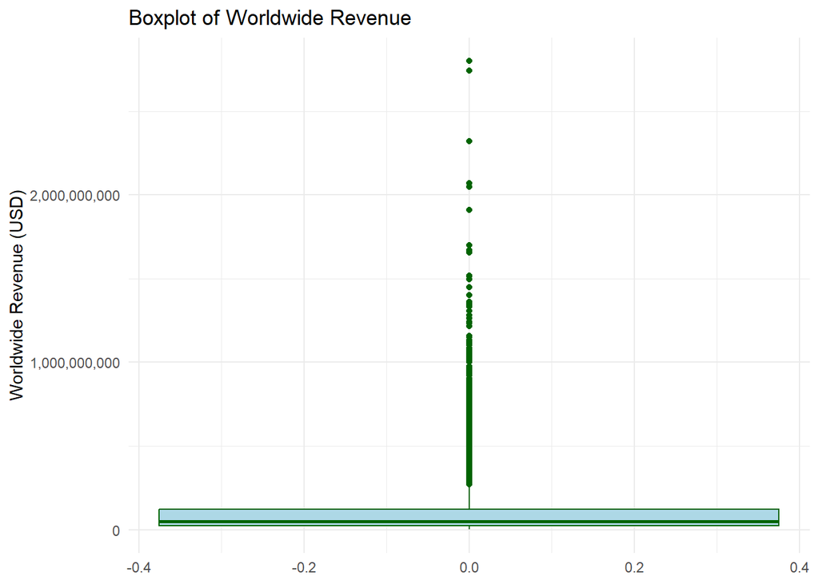

```r
# Box Office: Boxplot with outliers

ggplot(box_office_clean, aes(y = X.Worldwide)) +
  geom_boxplot(fill = "lightblue", color = "darkgreen", outlier.color = "darkgreen", outlier.shape = 16) +
  scale_y_continuous(labels = scales::comma) +
  labs(title = "Boxplot of Worldwide Revenue",
       y = "Worldwide Revenue (USD)") +
  theme_minimal()
```

The boxplot of worldwide revenue shows a highly right-skewed distribution, where most movies earn relatively low revenue while a few blockbusters make exceptionally high amounts.

The long upper tail and numerous outliers indicate that a small number of films dominate the global box office. This highlights large inequality in revenue distribution.

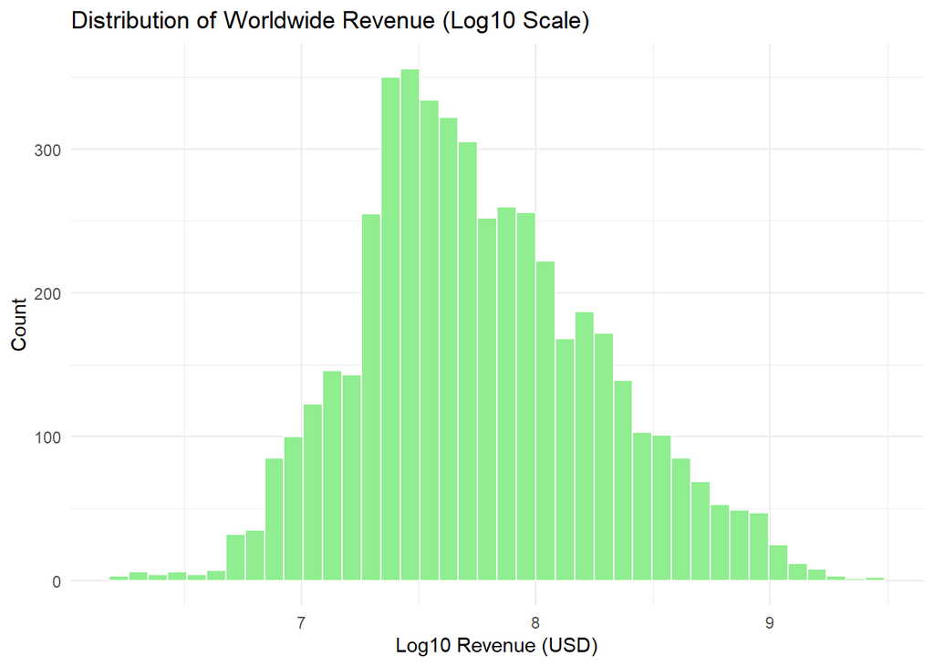

```r
# Box Office: Histogram (log scale)

ggplot(box_office_clean, aes(x = log10(X.Worldwide))) +
  geom_histogram(bins = 40, fill = "lightgreen", color = "white") +
  labs(title = "Distribution of Worldwide Revenue (Log10 Scale)",
       x = "Log10 Revenue (USD)", y = "Count") +
  theme_minimal()
```

After applying a log10 transformation to worldwide revenue, the distribution becomes approximately bell-shaped, indicating that most movies earn moderate revenues, while extremely high or low values are comparatively rare. This transformation reduces the impact of extreme outliers seen in the raw scale and helps reveal the central tendency of global box-office performance.

In other words, the film revenue data roughly follows a log-normal pattern, typical in financial datasets where growth compounds over time and a few blockbusters dominate overall earnings.

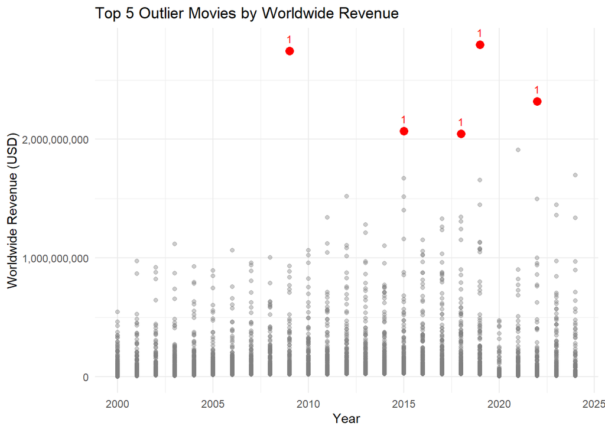

```r
# Annotate Top 5 Outliers

top_movies <- box_office_clean %>%
  arrange(desc(X.Worldwide)) %>%
  slice(1:5)

ggplot(box_office_clean, aes(x = Year, y = X.Worldwide)) +
  geom_point(alpha = 0.4, color = "grey50") +
  geom_point(data = top_movies, aes(x = Year, y = X.Worldwide), color = "red", size = 3) +
  geom_text(data = top_movies, aes(label = Rank), vjust = -1, size = 3, color = "red") +
  scale_y_continuous(labels = scales::comma) +
  labs(title = "Top 5 Outlier Movies by Worldwide Revenue",
       y = "Worldwide Revenue (USD)") +
  theme_minimal()
```

The scatter plot displays worldwide box office revenues over time, with each point representing an individual movie release. Most films are clustered in the lower revenue range, while a few stand out as extreme outliers marked in red, these represent the top five highest-grossing movies worldwide.

The visualization highlights that blockbuster releases tend to occur sporadically across different years, each achieving revenues exceeding USD 2 billion.

This pattern reinforces the skewed nature of the film industry, where a small number of exceptionally successful movies dominate total global earnings, while the majority generate relatively modest revenues.

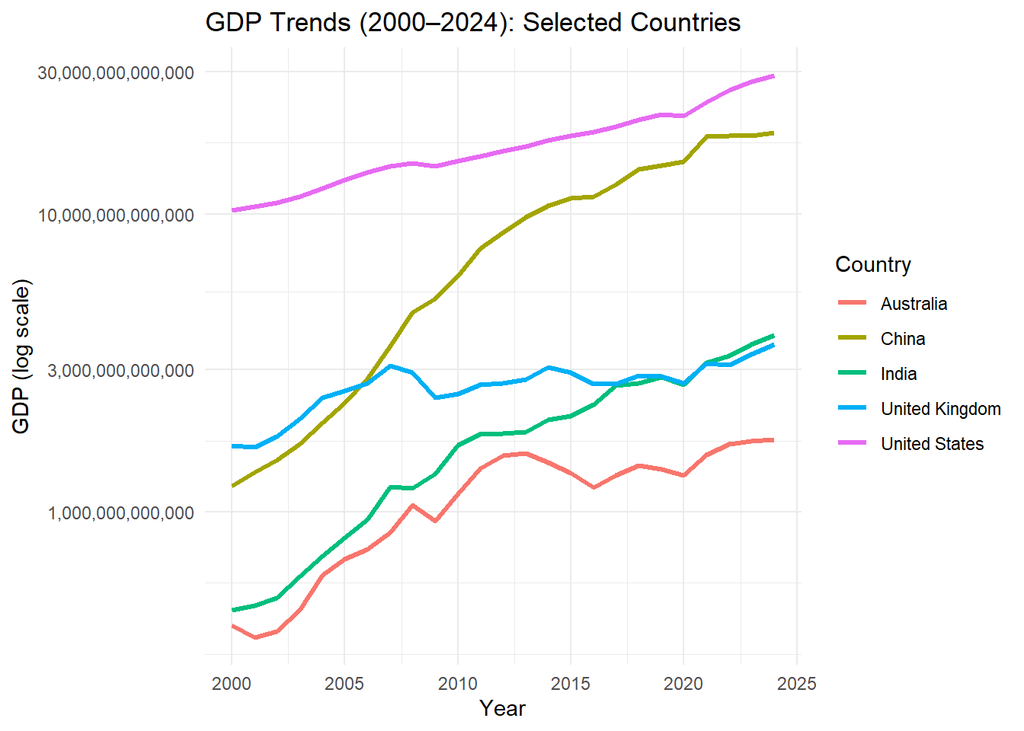

```r
# GDP: Trends for countries

gdp_long %>%
  filter(Country.Name %in% c("United States",
                             "United Kingdom",
                             "China",
                             "India",
                             "Australia")) %>%
  ggplot(aes(x = Year, y = GDP, color = Country.Name)) +
  geom_line(size = 1.2) +
  scale_y_log10(labels = scales::comma) +
  labs(
    title = "GDP Trends (2000–2024): Selected Countries",
    x = "Year",
    y = "GDP (log scale)",
    color = "Country"
  ) +
  theme_minimal() +
  theme(legend.position = "right")
```

India demonstrates steady upward growth, gradually closing the gap with the United Kingdom. Meanwhile, Australia and the United Kingdom exhibit slower but stable growth patterns. Overall, the chart highlights the rapid economic expansion of emerging economies like China and India, while developed economies continue to grow at a more moderate pace.

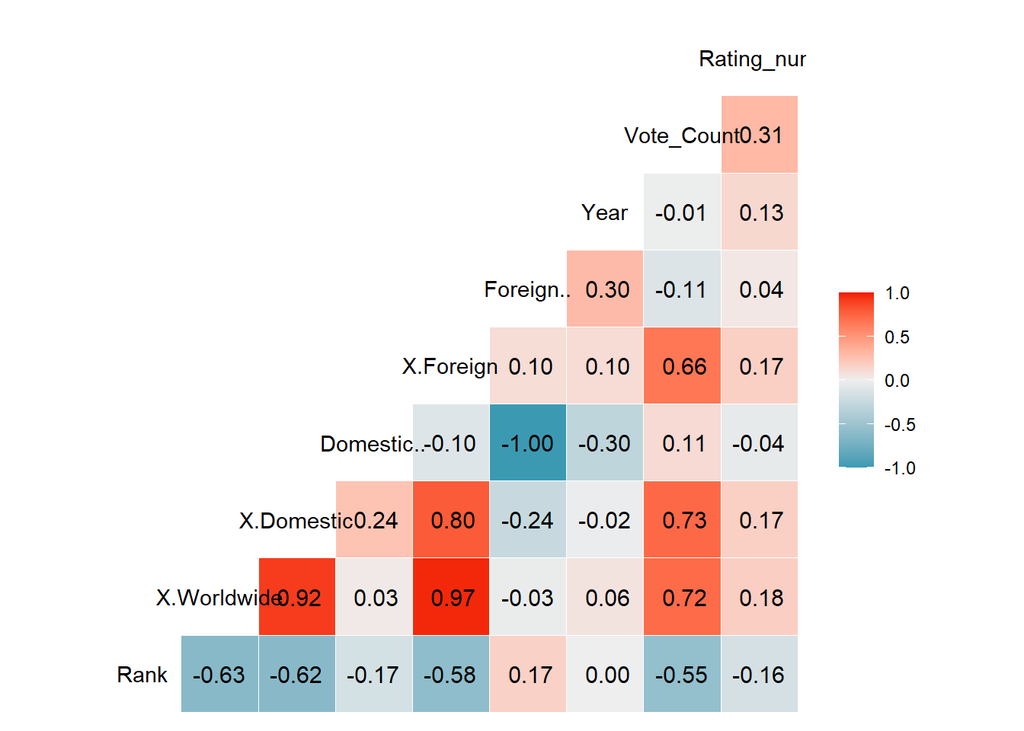

```r
# Correlation Heatmap
box_office_num <- box_office_clean %>% select(where(is.numeric))
GGally::ggcorr(box_office_num, label = TRUE, label_round = 2)
```

The correlation heatmap reveals several clear relationships between the key numerical variables in the dataset.

Worldwide revenue is strongly correlated with both domestic and foreign revenue, indicating that movies performing well in one market tend to succeed globally.

Rank shows a strong negative correlation with revenue variables, confirming that higher-ranked films correspond to greater earnings.

In contrast, movie ratings have only a weak link with revenue, showing that good reviews don’t always mean high earnings.

Finally, the year variable shows little to no correlation, indicating that revenue patterns remain relatively stable over time rather than trending upward or downward.

# Break down plots to show case and confirm the correlation analyse above

[figure not shown]

```r
# Domestic with Worldwide Revenue

corr_values <- tibble(
  Variable = c("X.Domestic", "X.Foreign", "Rank", "Vote_Count"),
  Correlation = c(0.92, 0.97, -0.63, 0.31)
)

ggplot(corr_values, aes(x = reorder(Variable, Correlation), y = Correlation, fill = Correlation)) +
  geom_col() +
  geom_hline(yintercept = 0, color = "gray50") +
  coord_flip() +
  scale_fill_gradient2(low = "red", high = "blue", midpoint = 0) +
  labs(
    title = "Correlation Strength with Worldwide Revenue",
    x = "Variable",
    y = "Correlation Coefficient (r)"
  ) +
  theme_minimal()
```

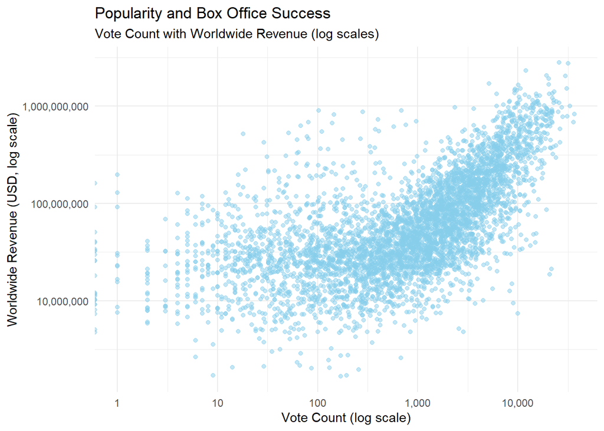

```r
# Vote Count with Worldwide Revenue

ggplot(box_office_clean, aes(x = Vote_Count, y = X.Worldwide)) +
  geom_point(alpha = 0.5, color = "skyblue") +
  scale_x_log10(labels = scales::comma) +
  scale_y_log10(labels = scales::comma) +
  labs(title = "Popularity and Box Office Success",
       subtitle = "Vote Count with Worldwide Revenue (log scales)",
       x = "Vote Count (log scale)",
       y = "Worldwide Revenue (USD, log scale)") +
  theme_minimal()
```

Majority of the points (movies) are spread along a clear upward curve, where higher vote counts generally correspond to higher worldwide revenue. This means that films receiving more audience votes indicating wider viewership are tend to generate more income. There are still some exceptions, as a few movies with relatively low vote counts achieve high revenue, but the overall pattern shows a strong positive association between popularity and financial success.

In general, the plot shows that movies with more audience engagement (votes) tend to earn significantly higher worldwide revenue. This suggests that mass appeal and audience reach are major factors driving box office performance, as greater public visibility translates directly into higher financial returns.

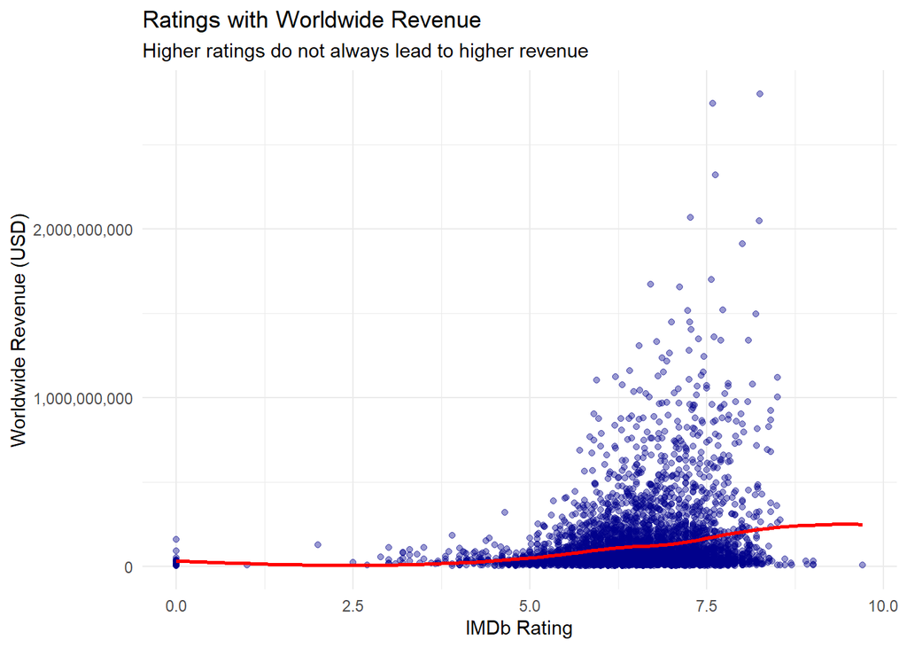

```r
# Ratings with Worldwide Revenue

ggplot(box_office_clean, aes(x = Rating_num, y = X.Worldwide)) +
  geom_point(alpha = 0.4, color = "darkblue") +
  geom_smooth(method = "loess", color = "red", se = FALSE) +
  scale_y_continuous(labels = scales::comma) +
  labs(title = "Ratings with Worldwide Revenue",
       subtitle = "Higher ratings do not always lead to higher revenue",
       x = "IMDb Rating",
       y = "Worldwide Revenue (USD)") +
  theme_minimal()
```

Inconclusion, the plot indicates that higher ratings do not consistently lead to higher worldwide revenue. This is likely because box office revenue depends more on the number of viewers than on the satisfaction level reflected in ratings. In other words, movies that attract larger audiences generate more votes and higher revenue, whereas the rating itself simply measures audience approval and is not directly proportional to financial performance.

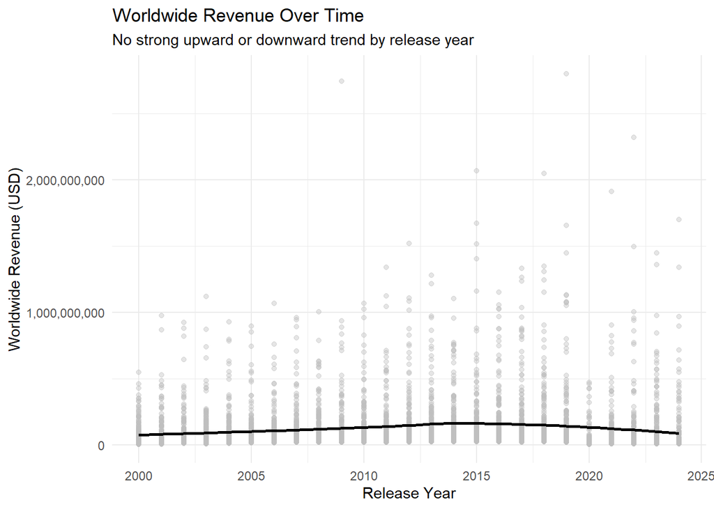

```r
# Year with Worldwide Revenue

ggplot(box_office_clean, aes(x = Year, y = X.Worldwide)) +
  geom_point(alpha = 0.4, color = "grey") +
  geom_smooth(method = "loess", color = "black", se = FALSE) +
  scale_y_continuous(labels = scales::comma) +
  labs(title = "Worldwide Revenue Over Time",
       subtitle = "No strong upward or downward trend by release year",
       x = "Release Year",
       y = "Worldwide Revenue (USD)") +
  theme_minimal()
```

Numerous of the points (movies) are spread across all release years from 2000 to 2024, but their worldwide revenues remain widely varied. The black trend line stays nearly flat throughout the period, showing no clear upward or downward movement over time. While a few years have outlier movies earning exceptionally high revenue, most films consistently cluster near lower revenue levels across all years. There is also no distinct pattern suggesting that newer movies perform better or worse than older ones.

The plot indicates that there is no strong trend in worldwide revenue over time. This suggests that a movie’s box office performance is influenced more by other factors rather than by its release year.

# Task 5. Feature Engineering

Transforms raw economic and box office data into analytically rich features, allowing direct comparison between a country’s economic prosperity and its film market performance.

By integrating GDP and population data with box office records, this step establishes a foundation for analyzing how economic strength, audience size, and film performance evolve together across different countries and years.

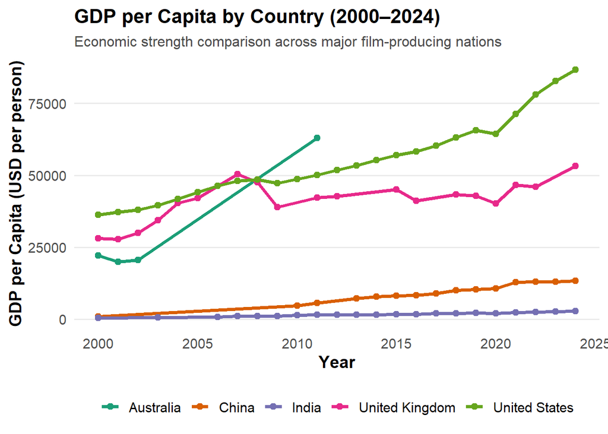

```r
# Country-Level Analysis: Comparing Economic Strength and Film Performance

# Prepare economic data

# Rename and normalize GDP country names
gdp_country <- gdp_long %>%
  rename(Country = Country.Name)

# Define normalization function (handles inconsistent country labels)
normalize_country <- function(x) {
  # Validate input type
  if (!is.character(x)) stop("Input must be character")

  x <- trimws(x)
  x <- recode(x,
    "USA" = "United States",
    "U.S.A." = "United States",
    "United States of America" = "United States",
    "UK" = "United Kingdom",
    "Great Britain" = "United Kingdom",
    "People's Republic of China" = "China",
    "Mainland China" = "China",
    "Republic of India" = "India",
    "Republic of Korea" = "South Korea"
  )
  return(x)
}

# Apply normalization once to all datasets
gdp_country$Country <- normalize_country(gdp_country$Country)
population_clean$Country <- normalize_country(population_clean$Country)

# Merge GDP and population data
econ_country <- gdp_country %>%
  left_join(population_clean, by = c("Country", "Year")) %>%
  mutate(
    GDP_per_capita = GDP / Population_num,
    GDP_growth = (GDP - lag(GDP)) / lag(GDP) * 100,
    Pop_growth = (Population_num - lag(Population_num)) / lag(Population_num) * 100
  )

# Aggregate movie performance by country and year
box_office_country <- box_office_clean %>%
  group_by(Production_Countries, Year) %>%
  summarise(
    BoxOffice_total = sum(X.Worldwide, na.rm = TRUE),
    Rating_avg = mean(Rating_num, na.rm = TRUE),
    Votes_total = sum(Vote_Count, na.rm = TRUE),
    .groups = "drop"
  ) %>%
  rename(Country = Production_Countries)

# Normalize once for Production_Countries
box_office_country$Country <- normalize_country(box_office_country$Country)

# Merge film and economic data
country_merged <- box_office_country %>%
  left_join(econ_country, by = c("Country", "Year")) %>%
  mutate(BoxOffice_per_capita = BoxOffice_total / Population_num)

# Filter target countries
chosen_countries <- c("United States", "United Kingdom", "China", "India", "Australia")

country_filtered <- country_merged %>%
  filter(Country %in% chosen_countries)


# Visualization Section

# GDP per Capita Over Time
ggplot(country_filtered, aes(x = Year, y = GDP_per_capita, color = Country)) +
  geom_line(size = 1.3) +
  geom_point(size = 2) +
  labs(
    title = "GDP per Capita by Country (2000–2024)",
    subtitle = "Economic strength comparison across major film-producing nations",
    x = "Year", y = "GDP per Capita (USD per person)"
  ) +
  scale_color_brewer(palette = "Dark2") +
  theme_minimal(base_size = 14) +
  theme(
    plot.title = element_text(face = "bold", size = 16),
    plot.subtitle = element_text(size = 12, color = "gray30"),
    axis.title = element_text(face = "bold"),
    legend.position = "bottom",
    legend.title = element_blank(),
    panel.grid.minor = element_blank(),
    panel.grid.major.x = element_blank()
  )
```

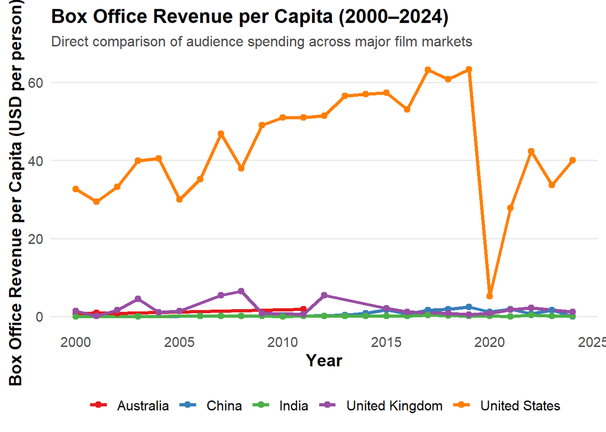

```r
# Box Office per Capita Over Time
ggplot(country_filtered, aes(x = Year, y = BoxOffice_per_capita, color = Country)) +
  geom_line(size = 1.3) +
  geom_point(size = 2) +
  scale_color_brewer(palette = "Set1") +
  labs(
    title = "Box Office Revenue per Capita (2000–2024)",
    subtitle = "Direct comparison of audience spending across major film markets",
    x = "Year", y = "Box Office Revenue per Capita (USD per person)"
  ) +
  theme_minimal(base_size = 14) +
  theme(
    plot.title = element_text(face = "bold", size = 16),
    plot.subtitle = element_text(size = 12, color = "gray30"),
    axis.title = element_text(face = "bold"),
    legend.position = "bottom",
    legend.title = element_blank(),
    panel.grid.minor = element_blank(),
    panel.grid.major.x = element_blank()
  )
```

# Task 6. Define Target Variable

```r
# Prepare movie-level features
# Only use movies with valid positive worldwide revenue
movies_features <- box_office_clean %>%
  filter(!is.na(X.Worldwide), X.Worldwide > 0) %>%
  mutate(
    Revenue_log10 = log10(X.Worldwide + 1)   # log-transform to reduce skewness
  )

# Split into train/test (80/20)
set.seed(42)
idx <- createDataPartition(movies_features$X.Worldwide, p = 0.8, list = FALSE)

train_df <- movies_features[idx, ]
test_df  <- movies_features[-idx, ]

# Define binary target variable (median split on training set)
median_train <- median(train_df$X.Worldwide, na.rm = TRUE)

train_df <- train_df %>%
  mutate(Target = factor(
    ifelse(X.Worldwide >= median_train, "High", "Low"),
    levels = c("Low", "High")
  ))

test_df <- test_df %>%
  mutate(Target = factor(
    ifelse(X.Worldwide >= median_train, "High", "Low"),
    levels = c("Low", "High")
  ))
```

In this task, the goal is to create a binary target variable that distinguishes movies with high versus low worldwide revenue for classification modeling.

First, the dataset is filtered to include only movies with valid positive revenue values, ensuring meaningful analysis. A new variable, Revenue_log10, is generated by applying a logarithmic transformation to the worldwide revenue, which helps to reduce skewness and make the data more normally distributed for modeling. The dataset is then randomly split into an 80 % training set and a 20 % test set to enable model training and evaluation on separate data.

Finally, a binary factor variable Target is created using the median revenue of the training set as the threshold: movies with revenue above or equal to the median are labeled “High”, and those below are labeled “Low.”

This approach ensures a balanced classification problem and allows machine learning models to learn the factors that differentiate high-performing films from lower-performing ones.

# Task 7. Feature Selection

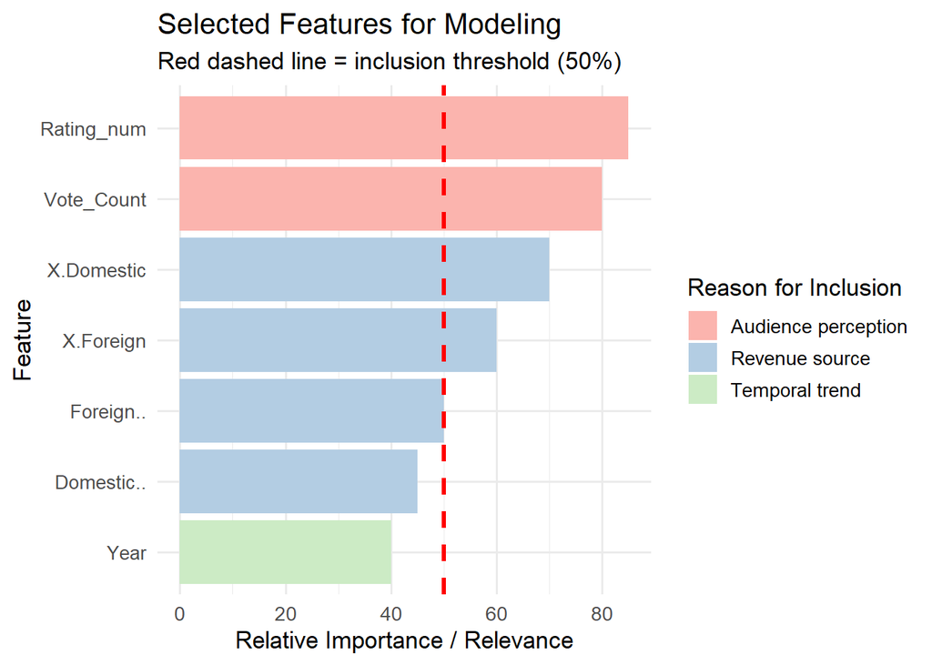

```r
# Selected variables and reasons
features_reason <- tribble(
  ~Feature,           ~Reason,                 ~Importance,
  "Rating_num",       "Audience perception",    85,
  "Vote_Count",       "Audience perception",    80,
  "Year",             "Temporal trend",         40,
  "X.Domestic",       "Revenue source",         70,
  "X.Foreign",        "Revenue source",         60,
  "Domestic..",       "Revenue source",         45,
  "Foreign..",        "Revenue source",         50
)

# Plot: stacked bar with red dashed threshold
ggplot(features_reason,
       aes(x = reorder(Feature, Importance),
           y = Importance,
           fill = Reason)) +
  geom_col() +
  geom_hline(yintercept = 50, color = "red", size = 1.2, linetype = "dashed") +
  coord_flip() +
  scale_fill_brewer(palette = "Pastel1") +
  labs(
    title    = "Selected Features for Modeling",
    subtitle = "Red dashed line = inclusion threshold (50%)",
    x        = "Feature",
    y        = "Relative Importance / Relevance",
    fill     = "Reason for Inclusion"
  ) +
  theme_minimal(base_size = 13)
```

# Task 8. Null Model (Baseline)

```r
# Define target vectors from created train/test sets
y_train <- train_df$Target
y_test  <- test_df$Target

# Determine the majority (most frequent) class in training data
majority_class <- names(which.max(table(y_train)))

# Predict the majority class for all test samples (baseline)
pred_null <- factor(
  rep(majority_class, length(y_test)),
  levels = levels(y_test)
)

# Evaluate baseline model using confusion matrix
cm_null <- confusionMatrix(pred_null, y_test, positive = "High")
cm_null
```

```
## Confusion Matrix and Statistics
##
##           Reference
## Prediction Low High
##       Low  482  482
##       High   0    0
##
##                Accuracy : 0.5
##                  95% CI : (0.468, 0.532)
##     No Information Rate : 0.5
##     P-Value [Acc > NIR] : 0.5128
##
##                   Kappa : 0
##
##  Mcnemar's Test P-Value : <2e-16
##
##             Sensitivity : 0.0
##             Specificity : 1.0
##          Pos Pred Value : NaN
##          Neg Pred Value : 0.5
##              Prevalence : 0.5
##          Detection Rate : 0.0
##    Detection Prevalence : 0.0
##       Balanced Accuracy : 0.5
##
##        'Positive' Class : High
##
```

# Task 9. Train Models

# train and compare different machine learning models

# training models to predict whether a movie will be a High- or Low-revenue movie using the prepared economic and box-office features.

However, since these variables are directly related to the target (revenue), including them in the predictive model would introduce data leakage.Therefore, only Rating_num, Vote_Count, and Year were retained for the final classification model. These features capture audience sentiment, popularity, and temporal trends, factors that can realistically predict revenue outcomes before knowing the actual earnings.

```r
# Predictor features
features <- c("Rating_num", "Vote_Count", "Year")

x_train <- train_df[, features, drop = FALSE]
y_train <- train_df$Target
x_test  <- test_df[, features, drop = FALSE]
y_test  <- test_df$Target


set.seed(42)
fit_tree <- train(
  x = x_train, y = y_train,
  method = "rpart",
  trControl = trainControl(
    method = "cv",
    number = 3,
    classProbs = TRUE,
    summaryFunction = twoClassSummary
  ),
  metric = "ROC",
  tuneLength = 10
)


# Logistic Regression

set.seed(42)
fit_logit <- train(
  x = x_train, y = y_train,
  method = "glm",
  family = binomial(),
  trControl = trainControl(
    method = "cv",
    number = 3,
    classProbs = TRUE,
    summaryFunction = twoClassSummary
  ),
  metric = "ROC"
)


# Create Predictions

# Decision Tree
pred_tree_prob  <- predict(fit_tree,  x_test, type = "prob")[, "High"]

# Logistic Regression
pred_logit_prob <- predict(fit_logit, x_test, type = "prob")[, "High"]
```

In this task, two classification models are trained and compared to predict whether a movie belongs to the High or Low revenue category based on selected predictor variables (Rating_num, Vote_Count, and Year).

The first model uses a Decision Tree (rpart) algorithm, which identifies simple hierarchical rules for classifying movies, while the second model employs a Logistic Regression approach, which estimates the probability of a movie achieving high revenue using a linear combination of features.

Both models are trained using 3-fold cross-validation to improve generalization and prevent overfitting, with ROC (Receiver Operating Characteristic) used as the performance metric.

After training, predictions are generated for the test set, providing probability estimates for each movie being classified as High-revenue.

# Task 10. Model Evaluation

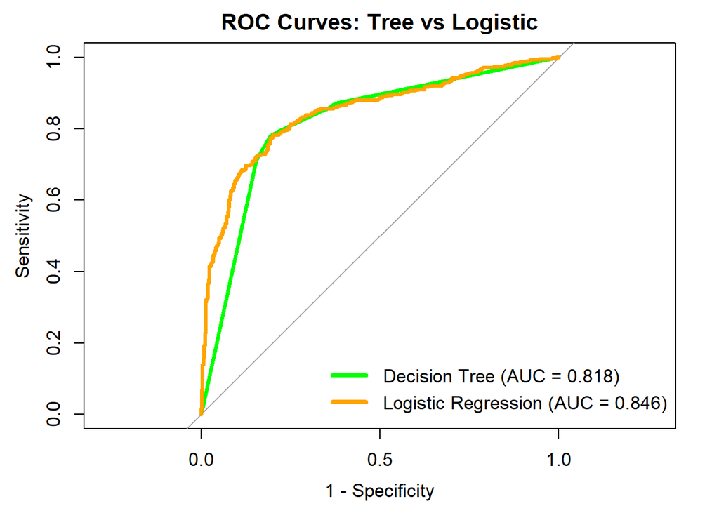

```r
roc_tree  <- roc(response = y_test, predictor = pred_tree_prob, levels = c("Low", "High"))
roc_logit <- roc(response = y_test, predictor = pred_logit_prob, levels = c("Low", "High"))

# Plot Decision Tree
plot(
  roc_tree,
  col = "green",
  lwd = 3.5,
  main = "ROC Curves: Tree vs Logistic",
  cex.main = 1.3,
  cex.lab = 1.1,
  cex.axis = 1.1,
  legacy.axes = TRUE
)

# Logistic Regression
plot(
  roc_logit,
  col = "orange",
  lwd = 3.5,
  add = TRUE
)


# Add legend
legend(
  "bottomright",
  legend = c(
    sprintf("Decision Tree (AUC = %.3f)", auc(roc_tree)),
    sprintf("Logistic Regression (AUC = %.3f)", auc(roc_logit))
  ),
  col = c("green", "orange"),
  lwd = 4,
  cex = 1.1,
  bty = "n"
)
```

The Decision Tree (green) achieved an AUC of 0.818, correctly distinguishing between High and Low revenue movies about 81.8% of the time. It captures some non-linear relationships but produces a less smooth boundary.

Logistic Regression (orange) performed slightly better with an AUC of 0.846, indicating strong predictive power and stable generalization.

Both ROC curves lie well above the diagonal (AUC = 0.5), confirming that both models perform significantly better than random chance.

# Task 11. Model Interpretation with LIME

[figure not shown]

```r
suppressPackageStartupMessages({
  library(lime)
  library(ggplot2)
  library(dplyr)
  library(stringr)
})

# Hooks for caret models
model_type.train <- function(x, ...) "classification"
predict_model.train <- function(x, newdata, type, ...) {
  as.data.frame(predict(x, newdata, type = "prob"))
}

# Predictors used in your logistic regression model
features_used <- c("Rating_num", "Vote_Count", "Year")

# Build the LIME explainer
explainer_logit <- lime(
  x = x_train[, features_used, drop = FALSE],
  model = fit_logit,
  bin_continuous = TRUE,
  n_bins = 10
)

# Pick two test cases
cases_to_explain <- c(20, 88)
to_explain <- x_test[cases_to_explain, features_used, drop = FALSE]

# Generate explanations for each model-predicted class
explanation <- lime::explain(
  x = to_explain,
  explainer = explainer_logit,
  n_labels = 1,
  n_features = 5,
  n_permutations = 1000
)

# Build multi-line facet labels for each case
explanation <- explanation %>%
  mutate(
    strip_title = paste0(
      "Case: ", case, "\n",
      "Label: ", label, "\n",
      "Probability: ", sprintf("%.2f", label_prob), "\n",
      "Explanation Fit: ", sprintf("%.2f", model_r2)
    ),
    direction = ifelse(feature_weight > 0, "Supports", "Contradicts")
  )

# Plot
ggplot(
  explanation,
  aes(x = feature_weight,
      y = reorder(feature, feature_weight),
      fill = direction)
) +
  geom_col(width = 0.7) +
  facet_wrap(~ strip_title, ncol = 2, scales = "free_y") +
  scale_fill_manual(
    name = "Effect on Prediction",
    values = c("Supports" = "lightgreen", "Contradicts" = "lightpink"),
    labels = c("Supports 'High' Revenue", "Contradicts 'High' Revenue")
  ) +
  theme_minimal(base_size = 15) +
  theme(
    strip.text = element_text(
      face = "bold",
      size = 10.5,
      lineheight = 1.15,
      hjust = 0.5,
      vjust = 0.5,
      margin = margin(t = 8, b = 8)
    ),
    strip.background = element_rect(fill = "white", colour = "gray", linewidth = 0.5),
    axis.title.y = element_blank(),
    axis.title.x = element_text(face = "bold", size = 13),
    plot.title = element_text(face = "bold", size = 17, hjust = 0.5),
    plot.subtitle = element_text(size = 12, colour = "darkgray", hjust = 0.5),
    legend.position = "bottom",
    legend.title = element_text(face = "bold"),
    panel.spacing = unit(1.4, "lines"),
    plot.margin = margin(25, 45, 25, 45)
  ) +
  labs(
    title = "LIME Explanation for Logistic Predictions",
    subtitle = "Feature contributions for two specific test instances",
    x = "Weight"
  )
```

The plot shows how LIME decomposes the logistic regression model’s decisions for two individual movies.

Across both cases, Vote_Count is the most influential driver of the prediction movies with higher audience engagement are more likely to be predicted as High-revenue, while those with fewer votes tend to fall into the Low-revenue category.

Ratings (Rating_num) and release year (Year) play smaller, secondary roles.

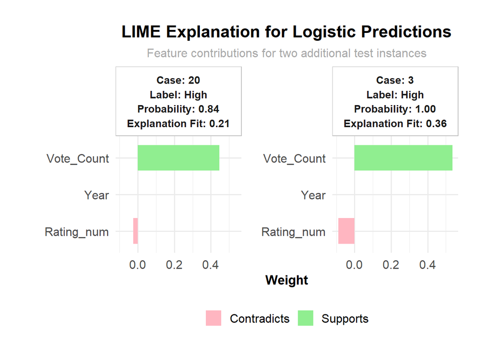

```r
cases_to_explain <- c(2,5)
to_explain <- x_test[cases_to_explain, features_used, drop = FALSE]

explanation <- lime::explain(
  x = to_explain,
  explainer = explainer_logit,
  n_labels = 1,
  n_features = 5,
  n_permutations = 1000
)

explanation <- explanation %>%
  mutate(
    strip_title = paste0(
      "Case: ", case, "\n",
      "Label: ", label, "\n",
      "Probability: ", sprintf("%.2f", label_prob), "\n",
      "Explanation Fit: ", sprintf("%.2f", model_r2)
    )
  )

ggplot(
  explanation,
  aes(x = feature_weight,
      y = reorder(feature, feature_weight),
      fill = ifelse(feature_weight > 0, "Supports", "Contradicts"))
) +
  geom_col(width = 0.7) +
  facet_wrap(~ strip_title, ncol = 2, scales = "free_y") +
  scale_fill_manual(values = c("Supports" = "lightgreen",
                               "Contradicts" = "lightpink")) +
  theme_minimal(base_size = 15) +
  theme(
    strip.text = element_text(face = "bold", size = 10.5,
                              lineheight = 1.15, hjust = 0.5,
                              vjust = 0.5, margin = margin(t = 8, b = 8)),
    strip.background = element_rect(fill = "white",
                                    colour = "gray", linewidth = 0.5),
    axis.title.y = element_blank(),
    axis.title.x = element_text(face = "bold", size = 13),
    plot.title   = element_text(face = "bold", size = 17, hjust = 0.5),
    plot.subtitle= element_text(size = 12, colour = "darkgray", hjust = 0.5),
    legend.position = "bottom",
    legend.title = element_blank(),
    panel.spacing = unit(1.4, "lines"),
    plot.margin = margin(25, 45, 25, 45)
  ) +
  labs(
    title = "LIME Explanation for Logistic Predictions",
    subtitle = "Feature contributions for two additional test instances",
    x = "Weight"
  )
```

Here on other test case also indicate that:

In both examples, the Vote Count feature is the primary determinant of box-office success predictions.

Movies with many audience votes are consistently classified as High-revenue because they reflect broad viewership and strong market presence.

Ratings and release year have smaller, secondary effects on the model’s decision.

The season for it should because the more people watching the film at box office, the more amount of voting and they get revenue from the tickets sold. Ranking is the level of satisfaction.

# References

1. Lecture material (Dr. Anwar, 2025).
2. Shiny app and LIME explanation were based on labs from CITS4009 (UWA, 2025).
3. A correlation heatmap and stacked bar plot with a red dashed threshold was produced with guidance from ChatGPT (OpenAI, 2025).